# Some examples of data analysis using **R**

Azti course on introduction to `R` statistical software

Dae-Jin Lee

dlee@bcamath.org

# The Forbes 2000 Ranking of the World’s Biggest Companies (Year 2004)

The data handling and manipulation techniques explained will be illustrated by means of a data set of 2000 world leading companies, the Forbes 2000 list for the year 2004 collected by Forbes Magazine. This list is originally available from `www.forbes.com`

Here we show a subset of the data set:

| rank | name | country | category | sales | profits | assets | marketvalue |
| --- | --- | --- | --- | --- | --- | --- | --- |
| 1 | Citigroup | United States | Banking | 94.71 | 17.85 | 1264.03 | 255.30 |
| 2 | General Electric | United States | Conglomerates | 134.19 | 15.59 | 626.93 | 328.54 |
| 3 | American Intl Group | United States | Insurance | 76.66 | 6.46 | 647.66 | 194.87 |
| 4 | ExxonMobil | United States | Oil & gas operations | 222.88 | 20.96 | 166.99 | 277.02 |
| 5 | BP | United Kingdom | Oil & gas operations | 232.57 | 10.27 | 177.57 | 173.54 |
| 6 | Bank of America | United States | Banking | 49.01 | 10.81 | 736.45 | 117.55 |

The data consists of 2000 observations on the following 8 variables.

- `rank`: the ranking of the company.
- `name`: the name of the company.
- `country`: a factor giving the country the company is situated in.
- `category`: a factor describing the products the company produces.
- `sales`: the amount of sales of the company in billion USD.
- `profits`: the profit of the company in billion USD.
- `assets`: the assets of the company in billion USD.
- `marketvalue`: the market value of the company in billion USD.

## Types of variables

`R` output

```
## 'data.frame':    2000 obs. of  8 variables:
##  $ rank       : int  1 2 3 4 5 6 7 8 9 10 ...
##  $ name       : chr  "Citigroup" "General Electric" "American Intl Group" "ExxonMobil" ...
##  $ country    : Factor w/ 61 levels "Africa","Australia",..: 60 60 60 60 56 60 56 28 60 60 ...
##  $ category   : Factor w/ 27 levels "Aerospace & defense",..: 2 6 16 19 19 2 2 8 9 20 ...
##  $ sales      : num  94.7 134.2 76.7 222.9 232.6 ...
##  $ profits    : num  17.85 15.59 6.46 20.96 10.27 ...
##  $ assets     : num  1264 627 648 167 178 ...
##  $ marketvalue: num  255 329 195 277 174 ...
```

## Factor levels

Nominal measurements are represented by factor variables in `R`, such as the country of the company or the category of the business segment.

A factor in `R` is divided into levels

How many countries are on the top 2000 ranking?

`R` output

```
## [1] 61
```

Which countries?

`R` output

```
##  [1] "Africa"                       "Australia"
##  [3] "Australia/ United Kingdom"    "Austria"
##  [5] "Bahamas"                      "Belgium"
##  [7] "Bermuda"                      "Brazil"
##  [9] "Canada"                       "Cayman Islands"
## [11] "Chile"                        "China"
## [13] "Czech Republic"               "Denmark"
## [15] "Finland"                      "France"
## [17] "France/ United Kingdom"       "Germany"
## [19] "Greece"                       "Hong Kong/China"
## [21] "Hungary"                      "India"
## [23] "Indonesia"                    "Ireland"
## [25] "Islands"                      "Israel"
## [27] "Italy"                        "Japan"
## [29] "Jordan"                       "Kong/China"
```

[output cut: 16 more lines]

And in the top 20?

`R` output

```
## [1] "France"                      "Japan"
## [3] "Netherlands"                 "Netherlands/ United Kingdom"
## [5] "Switzerland"                 "United Kingdom"
## [7] "United States"
```

As a simple summary statistic, the frequencies of the levels of such a factor variable can be found from

```
##
##                      France                       Japan
##                           2                           1
##                 Netherlands Netherlands/ United Kingdom
##                           1                           1
##                 Switzerland              United Kingdom
##                           1                           3
##               United States
##                          11
```

Which type of companies?

```
##  [1] "Aerospace & defense"              "Banking"
##  [3] "Business services & supplies"     "Capital goods"
##  [5] "Chemicals"                        "Conglomerates"
##  [7] "Construction"                     "Consumer durables"
##  [9] "Diversified financials"           "Drugs & biotechnology"
## [11] "Food drink & tobacco"             "Food markets"
## [13] "Health care equipment & services" "Hotels restaurants & leisure"
## [15] "Household & personal products"    "Insurance"
## [17] "Materials"                        "Media"
## [19] "Oil & gas operations"             "Retailing"
## [21] "Semiconductors"                   "Software & services"
## [23] "Technology hardware & equipment"  "Telecommunications services"
## [25] "Trading companies"                "Transportation"
## [27] "Utilities"
```

How many of each category?

```
##
##              Aerospace & defense                          Banking
##                               19                              313
##     Business services & supplies                    Capital goods
##                               70                               53
##                        Chemicals                    Conglomerates
##                               50                               31
##                     Construction                Consumer durables
##                               79                               74
##           Diversified financials            Drugs & biotechnology
##                              158                               45
##             Food drink & tobacco                     Food markets
##                               83                               33
## Health care equipment & services     Hotels restaurants & leisure
##                               65                               37
##    Household & personal products                        Insurance
##                               44                              112
##                        Materials                            Media
##                               97                               61
##             Oil & gas operations                        Retailing
##                               90                               88
##                   Semiconductors              Software & services
##                               26                               31
##  Technology hardware & equipment      Telecommunications services
##                               59                               67
##                Trading companies                   Transportation
##                               25                               80
##                        Utilities
##                              110
```

A simple summary statistics such as the mean, median, quantiles and range can be found from continuous variables such as `sales`

`R` output

```
##    Min. 1st Qu.  Median    Mean 3rd Qu.    Max.
##   0.010   2.018   4.365   9.697   9.548 256.300
```

## Simple Graphics

**Chambers et al. (1983)**, “there is no statistical tool that is as powerful as a well chosen graph”

Histograms and boxplots

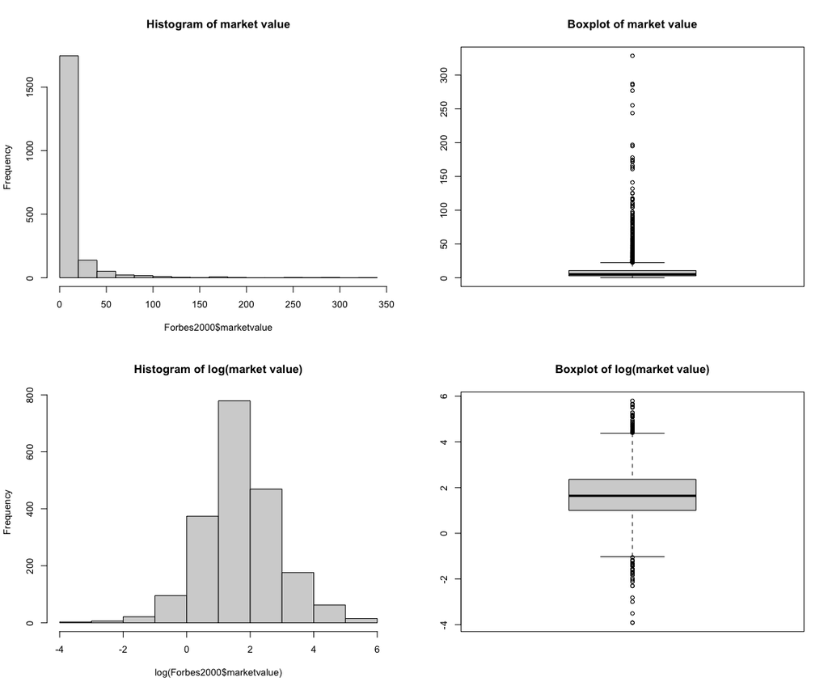

Scatterplots to visualize the relationship betwen variables

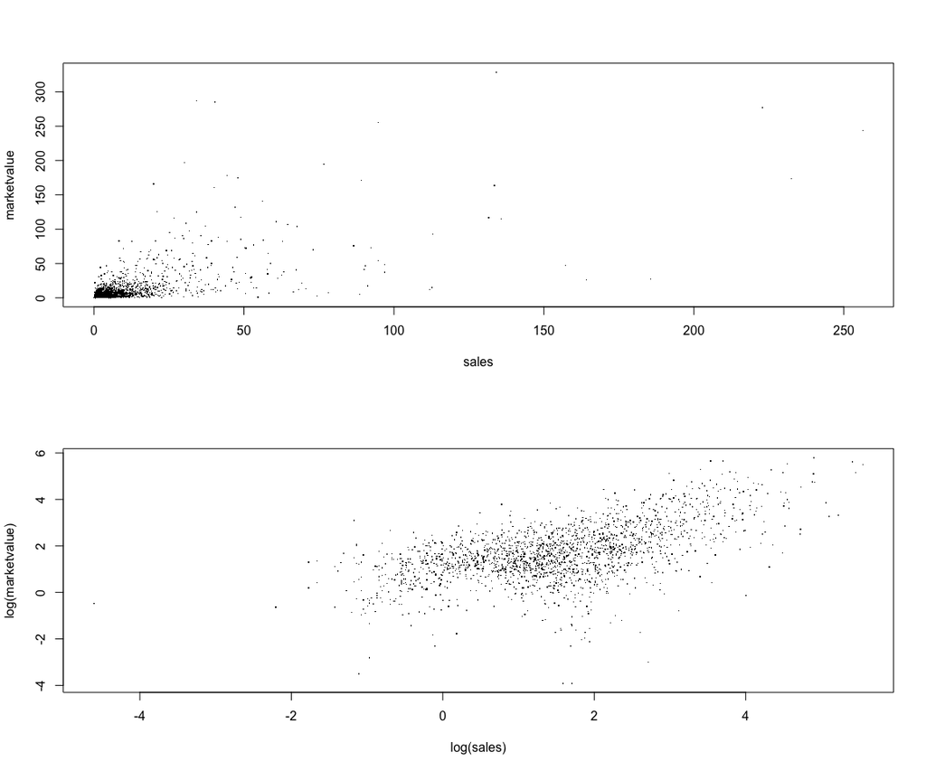

## Cool Graphics

Using the `ggplot2` library

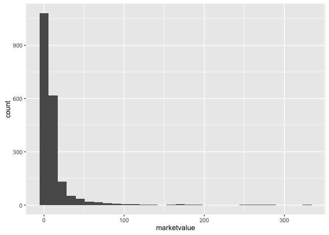

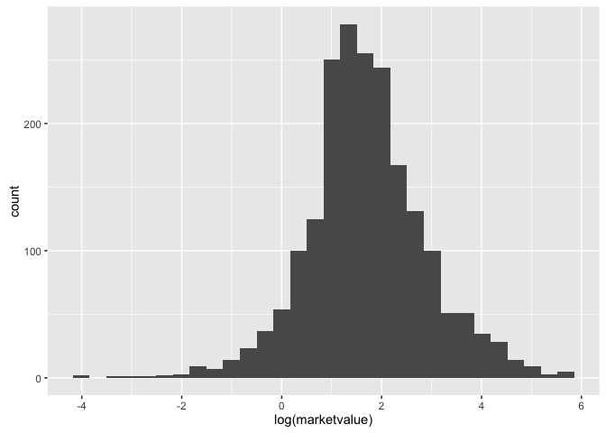

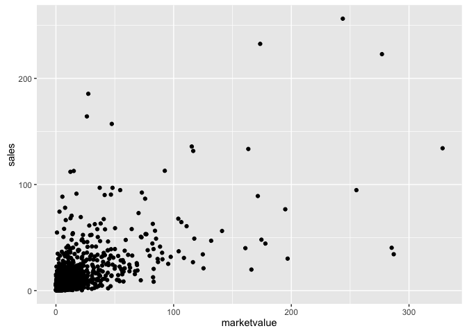

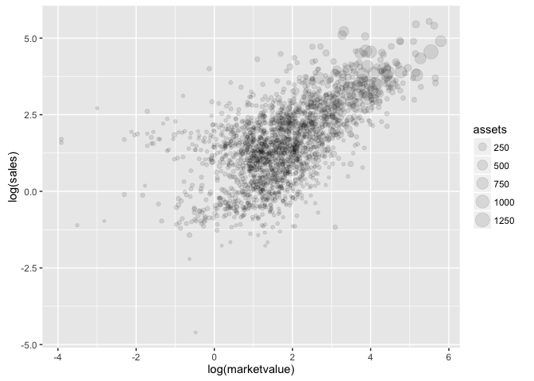

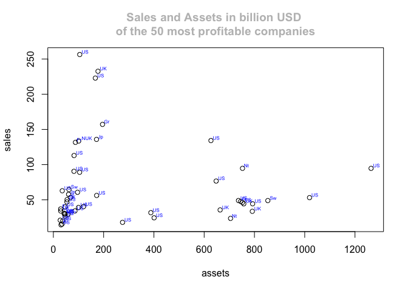

## Graphics by factor

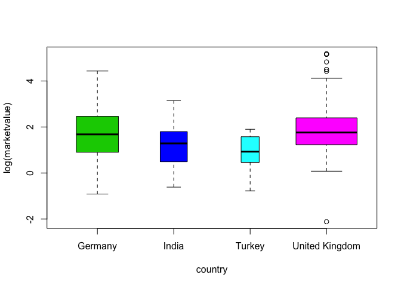

Scatterplots by country

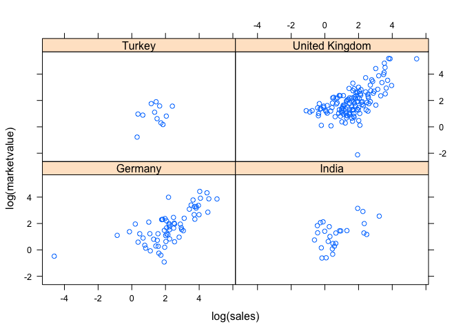

# Malignant Melanoma in the USA

Fisher and Belle (1993) report mortality rates due to malignant melanoma of the skin for white males during the period 1950-1969, for each state on the US mainland.

|  | mortality | latitude | longitude | ocean |
| --- | --- | --- | --- | --- |
| Alabama | 219 | 33.0 | 87.0 | yes |
| Arizona | 160 | 34.5 | 112.0 | no |
| Arkansas | 170 | 35.0 | 92.5 | no |
| California | 182 | 37.5 | 119.5 | yes |
| Colorado | 149 | 39.0 | 105.5 | no |
| Connecticut | 159 | 41.8 | 72.8 | yes |
| Delaware | 200 | 39.0 | 75.5 | yes |
| District of Columbia | 177 | 39.0 | 77.0 | no |
| Florida | 197 | 28.0 | 82.0 | yes |
| Georgia | 214 | 33.0 | 83.5 | yes |
| Idaho | 116 | 44.5 | 114.0 | no |
| Illinois | 124 | 40.0 | 89.5 | no |
| Indiana | 128 | 40.2 | 86.2 | no |
| Iowa | 128 | 42.2 | 93.8 | no |
| Kansas | 166 | 38.5 | 98.5 | no |
| Kentucky | 147 | 37.8 | 85.0 | no |
| Louisiana | 190 | 31.2 | 91.8 | yes |
| Maine | 117 | 45.2 | 69.0 | yes |
| Maryland | 162 | 39.0 | 76.5 | yes |
| Massachusetts | 143 | 42.2 | 71.8 | yes |
| Michigan | 117 | 43.5 | 84.5 | no |
| Minnesota | 116 | 46.0 | 94.5 | no |
| Mississippi | 207 | 32.8 | 90.0 | yes |
| Missouri | 131 | 38.5 | 92.0 | no |
| Montana | 109 | 47.0 | 110.5 | no |
| Nebraska | 122 | 41.5 | 99.5 | no |
| Nevada | 191 | 39.0 | 117.0 | no |
| New Hampshire | 129 | 43.8 | 71.5 | yes |
| New Jersey | 159 | 40.2 | 74.5 | yes |
| New Mexico | 141 | 35.0 | 106.0 | no |
| New York | 152 | 43.0 | 75.5 | yes |
| North Carolina | 199 | 35.5 | 79.5 | yes |
| North Dakota | 115 | 47.5 | 100.5 | no |
| Ohio | 131 | 40.2 | 82.8 | no |
| Oklahoma | 182 | 35.5 | 97.2 | no |
| Oregon | 136 | 44.0 | 120.5 | yes |
| Pennsylvania | 132 | 40.8 | 77.8 | no |
| Rhode Island | 137 | 41.8 | 71.5 | yes |
| South Carolina | 178 | 33.8 | 81.0 | yes |
| South Dakota | 86 | 44.8 | 100.0 | no |
| Tennessee | 186 | 36.0 | 86.2 | no |
| Texas | 229 | 31.5 | 98.0 | yes |
| Utah | 142 | 39.5 | 111.5 | no |
| Vermont | 153 | 44.0 | 72.5 | yes |
| Virginia | 166 | 37.5 | 78.5 | yes |
| Washington | 117 | 47.5 | 121.0 | yes |
| West Virginia | 136 | 38.8 | 80.8 | no |
| Wisconsin | 110 | 44.5 | 90.2 | no |
| Wyoming | 134 | 43.0 | 107.5 | no |

- `mortality`: number of white males died due to malignant melanoma 1950-1969 per one million inhabitants.
- `latitude`: latitude of the geographic centre of the state.
- `longitude`: longitude of the geographic centre of each state.
- `ocean`: a binary variable indicating contiguity to an ocean at levels `no` or `yes`.

## Plotting mortality rates

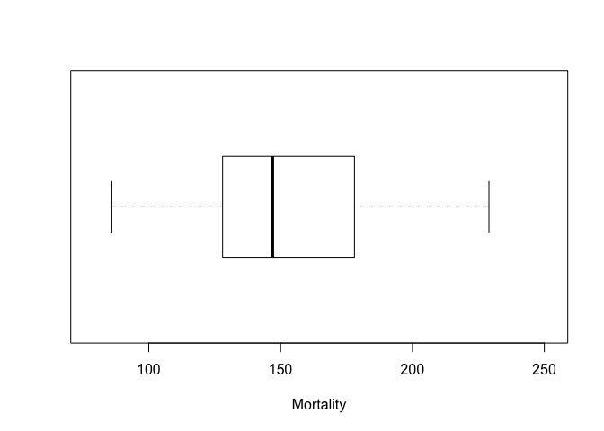

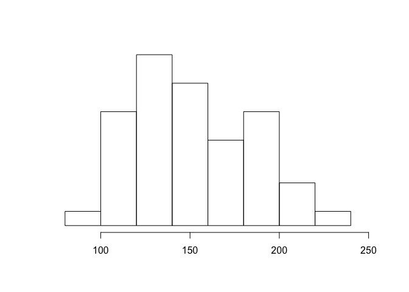

Malignant melanoma mortality rates by contiguity to an ocean

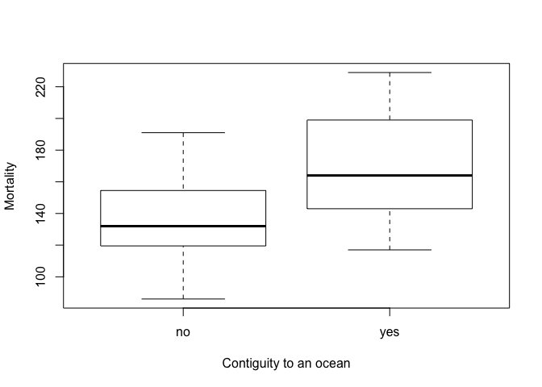

Histograms can often be misleading for displaying distributions because of their dependence on the number of classes chosen. An alternative is to formally estimate the density function of a variable and then plot the resulting estimate.

The estimated densities of malignant melanoma mortality rates by contiguity to an ocean looks like this:

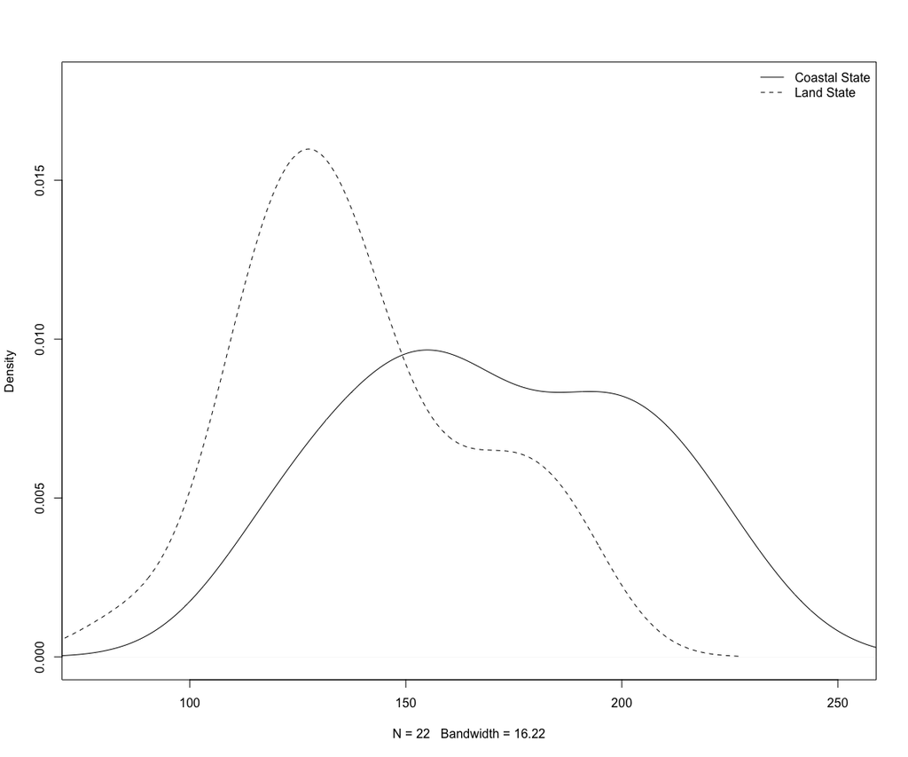

Now we might move on to look at how mortality rates are related to the geographic location of a state as represented by the latitude and longitude of the centre of the state.

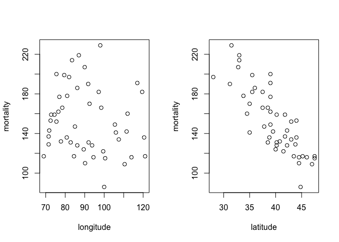

## Mapping mortality rates

The data contains the longitude and latitude of the centroids

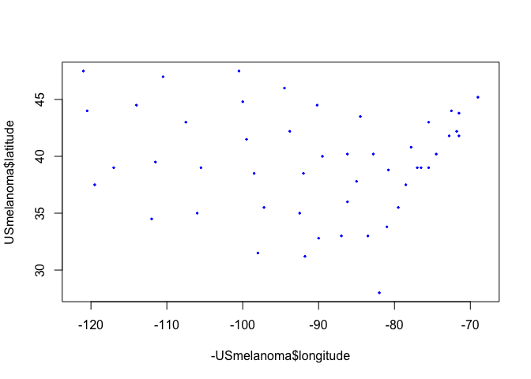

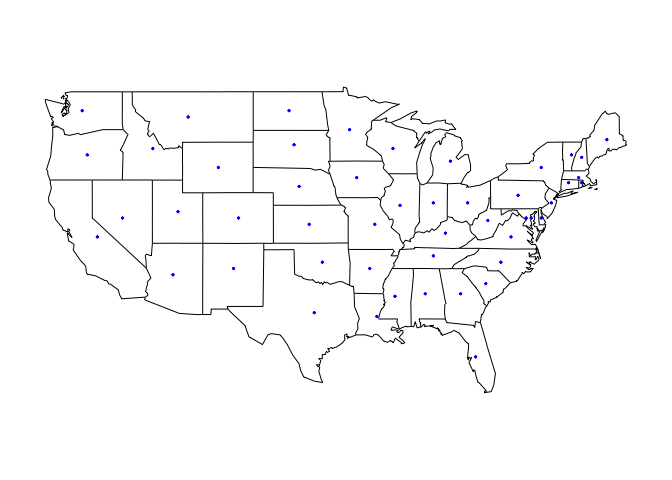

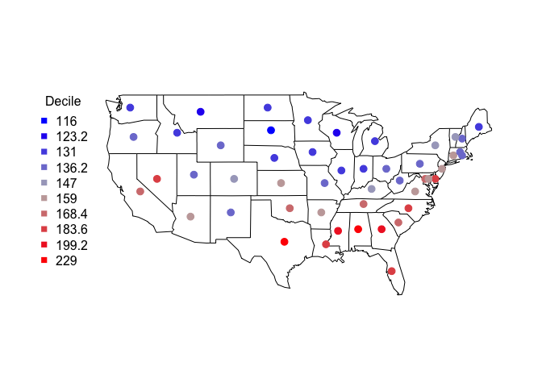

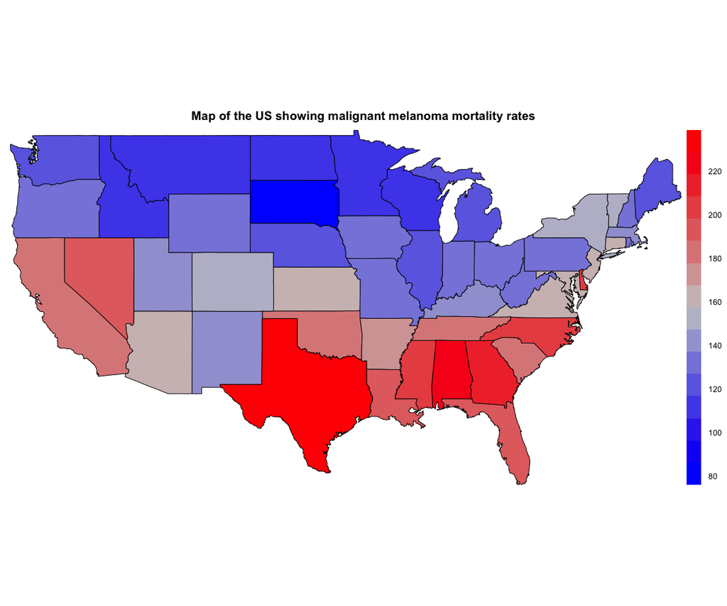

# Drug Adverse Event Discovery

We can use some statistical techniques (unsupervised classification) to identify which drugs are associated with which adverse events.

The data loooks like this (this is a simulated database):

| X | Route | Age | Sex | Outc_cod | Indi_pt | Pt |
| --- | --- | --- | --- | --- | --- | --- |
| 1 | ORAL | 63 | M | OT | RHEUMATOID ARTHRITIS | VASCULITIC RASH |
| 2 | ORAL | 66 | F | OT | RHEUMATOID ARTHRITIS | VASCULITIC RASH |
| 3 | ORAL | 66 | M | OT | RHEUMATOID ARTHRITIS | VASCULITIC RASH |
| 4 | ORAL | 57 | M | OT | RHEUMATOID ARTHRITIS | VASCULITIC RASH |
| 5 | ORAL | 66 | M | OT | RHEUMATOID ARTHRITIS | VASCULITIC RASH |
| 6 | ORAL | 66 | M | OT | RHEUMATOID ARTHRITIS | VASCULITIC RASH |
| 7 | ORAL | 64 | M | HO | RHEUMATOID ARTHRITIS | VASCULITIC RASH |
| 8 | ORAL | 56 | M | OT | RHEUMATOID ARTHRITIS | VASCULITIC RASH |
| 9 | ORAL | 66 | M | OT | RHEUMATOID ARTHRITIS | VASCULITIC RASH |
| 10 | ORAL | 66 | M | OT | RHEUMATOID ARTHRITIS | VASCULITIC RASH |
| 11 | ORAL | 52 | M | OT | RHEUMATOID ARTHRITIS | VASCULITIC RASH |
| 12 | ORAL | 66 | F | LT | RHEUMATOID ARTHRITIS | VASCULITIC RASH |
| 13 | ORAL | 59 | M | OT | RHEUMATOID ARTHRITIS | VASCULITIC RASH |
| 14 | ORAL | 61 | M | OT | RHEUMATOID ARTHRITIS | VASCULITIC RASH |
| 15 | ORAL | 66 | M | OT | RHEUMATOID ARTHRITIS | VASCULITIC RASH |
| 16 | ORAL | 66 | M | OT | RHEUMATOID ARTHRITIS | VASCULITIC RASH |
| 17 | ORAL | 48 | M | OT | RHEUMATOID ARTHRITIS | VASCULITIC RASH |
| 18 | ORAL | 60 | M | OT | RHEUMATOID ARTHRITIS | VASCULITIC RASH |
| 19 | ORAL | 62 | M | OT | RHEUMATOID ARTHRITIS | VASCULITIC RASH |
| 20 | ORAL | 60 | M | OT | RHEUMATOID ARTHRITIS | VASCULITIC RASH |
| 21 | ORAL | 18 | F | HO | URINARY TRACT INFECTION | VOMITING |
| 22 | TOPICAL | 15 | F | OT | URINARY TRACT INFECTION | VOMITING |
| 23 | TOPICAL | 14 | F | HO | URINARY TRACT INFECTION | VOMITING |
| 24 | TOPICAL | 17 | F | HO | URINARY TRACT INFECTION | VOMITING |
| 25 | TOPICAL | 17 | M | HO | URINARY TRACT INFECTION | VOMITING |
| 26 | TOPICAL | 17 | F | LT | URINARY TRACT INFECTION | VOMITING |
| 27 | TOPICAL | 18 | F | HO | URINARY TRACT INFECTION | VOMITING |
| 28 | TOPICAL | 17 | F | HO | URINARY TRACT INFECTION | VOMITING |
| 29 | TOPICAL | 24 | M | HO | URINARY TRACT INFECTION | VOMITING |
| 30 | TOPICAL | 17 | F | HO | URINARY TRACT INFECTION | VOMITING |
| 31 | TOPICAL | 20 | F | OT | URINARY TRACT INFECTION | VOMITING |
| 32 | TOPICAL | 17 | F | HO | URINARY TRACT INFECTION | VOMITING |
| 33 | TOPICAL | 17 | F | HO | URINARY TRACT INFECTION | VOMITING |
| 34 | INTRAVENOUS | 5 | F | LT | TONSILLITIS | VOMITING |
| 35 | INTRAVENOUS | 6 | M | LT | TONSILLITIS | VOMITING |
| 36 | INTRAVENOUS | 7 | F | LT | TONSILLITIS | VOMITING |
| 37 | INTRAVENOUS | 8 | F | HO | TONSILLITIS | VOMITING |
| 38 | INTRAVENOUS | 5 | F | LT | TONSILLITIS | VOMITING |
| 39 | INTRAVENOUS | 4 | M | LT | TONSILLITIS | VOMITING |
| 40 | INTRAVENOUS | 6 | F | LT | TONSILLITIS | VOMITING |
| 41 | INTRAVENOUS | 7 | F | LT | TONSILLITIS | VOMITING |
| 42 | INTRAVENOUS | 8 | F | OT | TONSILLITIS | VOMITING |
| 43 | INTRAVENOUS | 5 | F | LT | TONSILLITIS | VOMITING |
| 44 | INTRAVENOUS | 4 | M | LT | TONSILLITIS | VOMITING |
| 45 | INTRAVENOUS | 7 | F | OT | TONSILLITIS | VOMITING |
| 46 | INTRAVENOUS | 5 | F | LT | TONSILLITIS | VOMITING |
| 47 | INTRAVENOUS | 6 | F | LT | TONSILLITIS | VOMITING |
| 48 | INTRAVENOUS | 4 | F | LT | TONSILLITIS | VOMITING |
| 49 | OPHTHALMIC | 45 | F | DE | Senile osteoporosis | Sepsis |
| 50 | OPHTHALMIC | 43 | F | DE | Senile osteoporosis | Sepsis |
| 51 | OPHTHALMIC | 44 | F | LT | Senile osteoporosis | Sepsis |
| 52 | OPHTHALMIC | 42 | F | DE | Senile osteoporosis | Sepsis |
| 53 | ORAL | 40 | F | DE | Senile osteoporosis | Sepsis |
| 54 | OPHTHALMIC | 45 | F | DE | Senile osteoporosis | Sepsis |
| 55 | OPHTHALMIC | 48 | F | DE | Senile osteoporosis | Sepsis |
| 56 | OPHTHALMIC | 40 | F | HO | Senile osteoporosis | Sepsis |
| 57 | OPHTHALMIC | 42 | F | DE | Senile osteoporosis | Sepsis |
| 58 | ORAL | 45 | F | DE | Senile osteoporosis | Sepsis |
| 59 | OPHTHALMIC | 44 | F | DE | Senile osteoporosis | Sepsis |
| 60 | OPHTHALMIC | 43 | F | DE | Senile osteoporosis | Sepsis |
| 61 | OPHTHALMIC | 45 | F | OT | Senile osteoporosis | Sepsis |
| 62 | OPHTHALMIC | 46 | F | DE | Senile osteoporosis | Sepsis |
| 63 | OPHTHALMIC | 47 | F | DE | Senile osteoporosis | Sepsis |
| 64 | OPHTHALMIC | 45 | F | DE | Senile osteoporosis | Sepsis |
| 65 | OPHTHALMIC | 48 | F | DE | Senile osteoporosis | Sepsis |
| 66 | OPHTHALMIC | 49 | F | DE | Senile osteoporosis | Sepsis |
| 67 | OPHTHALMIC | 45 | F | DE | Senile osteoporosis | Sepsis |
| 68 | OPHTHALMIC | 44 | F | DE | Senile osteoporosis | Sepsis |
| 69 | OPHTHALMIC | 43 | F | DE | Senile osteoporosis | Sepsis |
| 70 | OPHTHALMIC | 45 | F | OT | Senile osteoporosis | Sepsis |
| 71 | OPHTHALMIC | 46 | F | DE | Senile osteoporosis | Sepsis |
| 72 | OPHTHALMIC | 47 | F | DE | Senile osteoporosis | Sepsis |

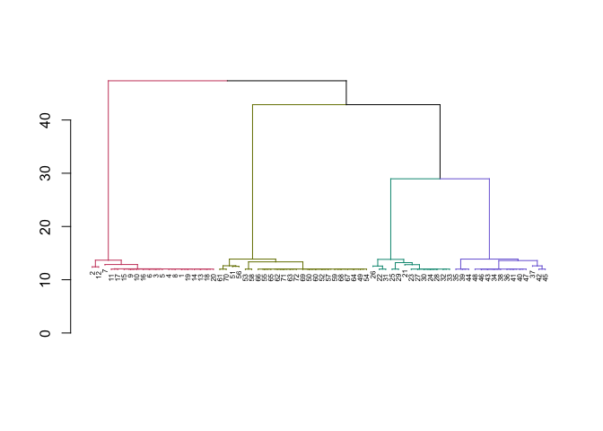

| cluster | Number_of_observations |
| --- | --- |
| 1 | 20 |
| 2 | 13 |
| 3 | 15 |
| 4 | 24 |

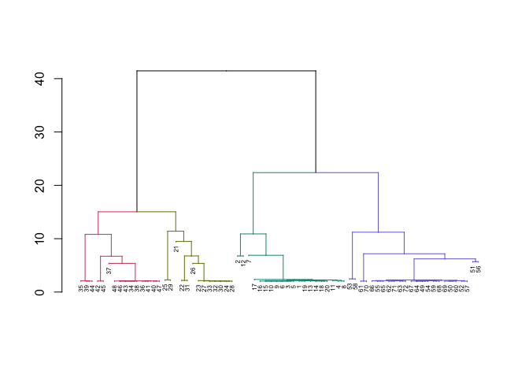

[output not shown]